# Forecast Evaluation and Combinations

Module 7 · Scoring, testing, and averaging forecasts

Gary Cornwall

Econ 6376 · The George Washington University

## Module 6 recap: a forecast is a point, an interval and a density

**Point**$\tilde y_{t+h\mid t}=\mathbb{E}\!\left[y_{t+h}\mid\mathcal{F}_t\right]$the headline number

**Interval**$\tilde y_{t+h\mid t}\pm c_h$with a stated coverage

**Density**$f(y_{t+h}\mid\mathcal{F}_t)$the whole distribution; the fan chart draws it

**Uncertainty grows with the horizon.**

$$\text{Var(}e_{t+h\mid t}\text{)}=\sigma^2\sum_{i=0}^{h-1}\psi_i^2$$

$h=1$: $\sigma^2$. Stationary: $\to\gamma_0$. Unit root: keeps growing.

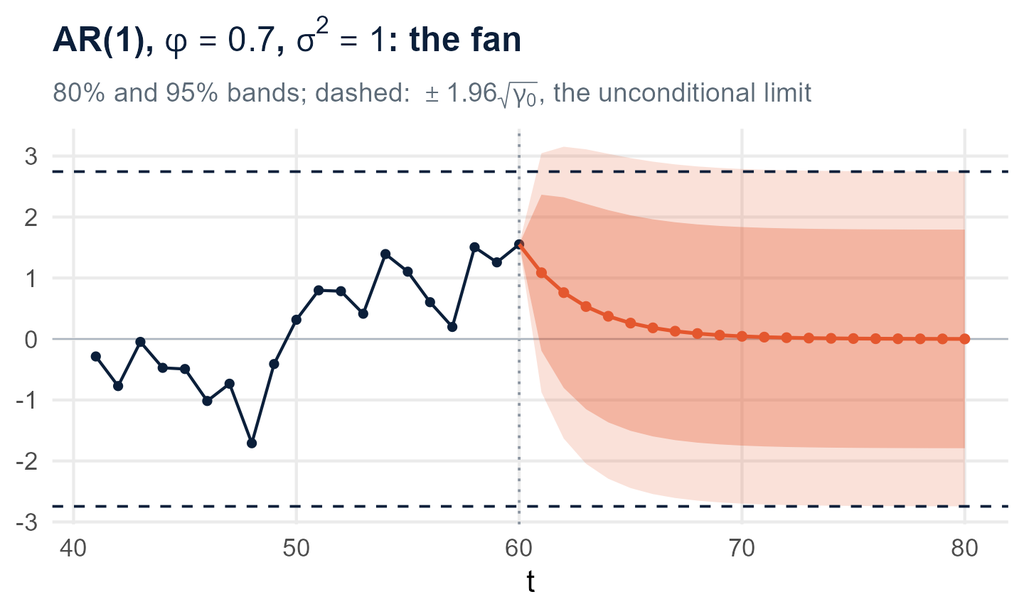

## Module 6 recap: the loss picks the target

Under **MSE**, the best point forecast is theconditional mean

Under **MAE**conditional median

Under **asymmetric linear loss** with weight $\alpha$the $\alpha$-quantile

**Huber and MAPE are losses too**; this course scores with them rather than deriving a target. MAPE is scale-free but undefined at $y_t=0$.

Choose the loss before you see the results; compare within a loss, never between: same loss, same $y$, same test observations $N$.

Today’s DM test takes a loss as an input. Which one, and who chooses?

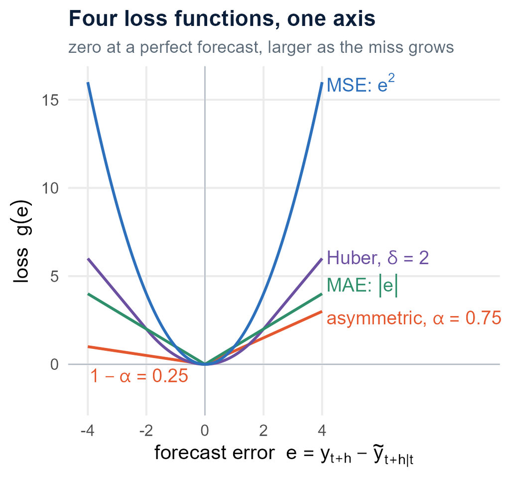

## Module 6 recap: train first, then test, in time order

Train: estimate here, onceUNRATE 1960-01 … 2017-12

Test24 months

1960origin: December 2017 → 2019

**Never a random split.** Shuffling leaks the future into training: Biff with the sports almanac.

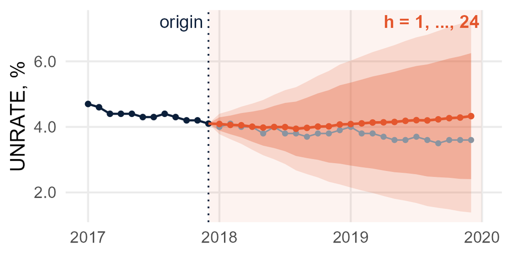

**Module 6: one origin, many horizons.** One fit, one path, $h=1,\ldots,24$.

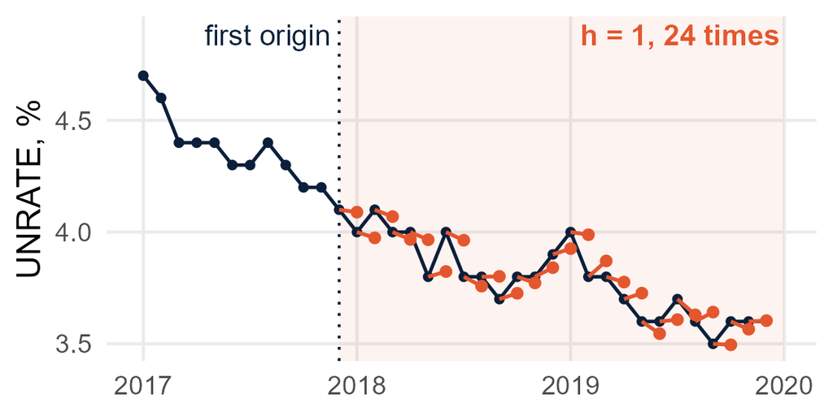

**Module 7: many origins, one horizon.** Fixed coefficients, rolling data.

Today: many origins, one horizon. Same parameters, the information set rolls.

## Why Choose Only One?

[Open Release Date Radar](https://grycrnwll.github.io/tools/release-date-radar.html)

## Debrief: the crowd average is a forecast combination

- Your guess of the release date is a forecast based on a mental model.
- Each of your models has partially overlapping information sets: you can exploit this!
- Each of you made a forecast $\tilde y^{(m)}$ of the release year, $m=1,\ldots,M$. The crowd mean is

$$\tilde y^{(c)}=\frac{1}{M}\sum_{m=1}^{M}\tilde y^{(m)}$$

the **simple average**: every weight $w_m=1/M$, nothing estimated.

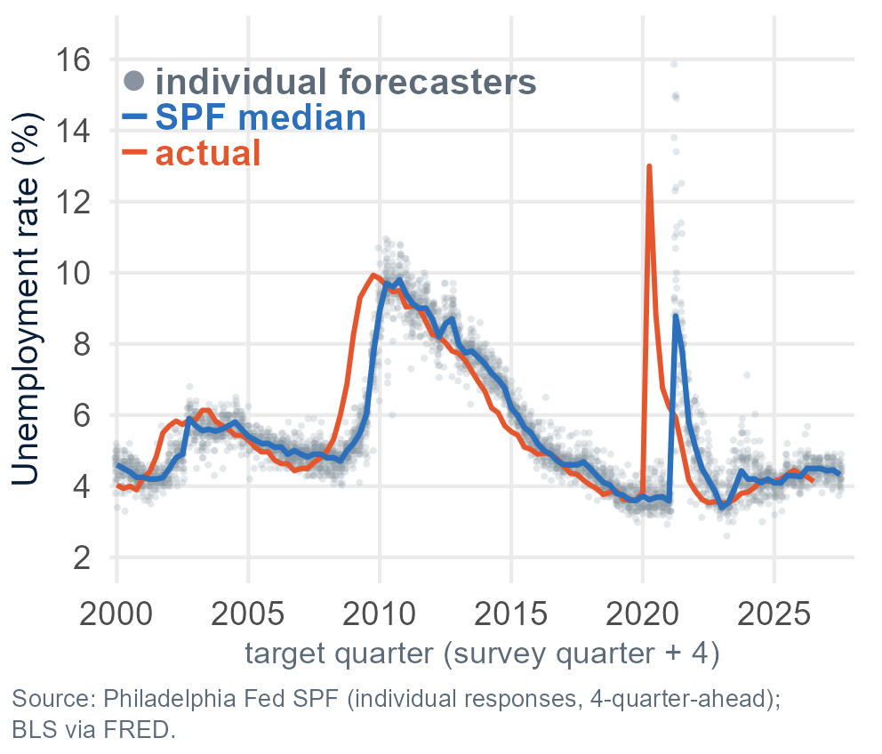

The SPF’s published forecast is the median across ~37 professional forecasters: forecast combination as standard practice.

## Where we are: nothing new on the mixing board

$$y_t=\alpha+\delta t+\sum_{j=1}^{p}\phi_j y_{t-j}+\sum_{l=1}^{q}\theta_l\epsilon_{t-l}+\epsilon_t$$

Every slider is on, seasonal block included. Module 6 projected one fitted equation forward; Module 7 puts several on the table and referees between them.

| Term | L4 | L5 | L6 | **L7** |
| --- | --- | --- | --- | --- |
| $\alpha$, $\delta t$ | On | On | On | On |
| $\phi_j y_{t-j}$ (all $p$) | On | On | On | On |
| $\theta_l\epsilon_{t-l}$ (all $q$) | On | On | On | On |
| Seasonal block $(P,D,Q)_s$ | Off | On | On | On |
| What we do with it | Select | Diagnose | Forecast | **Evaluate and combine $M$ forecasts** |

**Today’s arc, three questions:**

**1.** How do I score several forecasts?$U_2$, MASE

**2.** Is the difference real?Diebold-Mariano

**3.** Should I even pick one?combinations

## The PS3 design: many origins, one horizon

Train: estimate every model here, once$y_1,\ldots,y_T$, $T=N_{\text{total}}-24$

Weights window$T{+}1,\ldots,T{+}12$

Holdout$T{+}13,\ldots,T{+}24$

UNRATE 1960-01train to 2017-12 · weights 2018 · holdout 2019

**Parameters are estimated once**, on $y_1,\ldots,y_T$never again

**The information set rolls.** $\tilde y_{t\mid t-1}$ uses actuals up to $y_{t-1}$$h=1$ throughout

**Weights window**, $T_w=12$ dateswhere combination weights are estimated

**Holdout**, $N=12$ dateswhere everything is scored

One fit per model; at each date, the training coefficients meet the newest data:

```r
T_origin <- length(unrate) - 24  # Dec 2017
train_un <- upto(unrate, T_origin)
fit1 <- Arima(train_un, order = c(1, 1, 2),
  seasonal = list(order = c(1, 0, 1),
                  period = 12))
# one-step forecasts, coefficients frozen:
fitted(Arima(upto(unrate, T_origin + 24),
             model = fit1))
```

Subset a `ts` with `window()` (here `upto()`), never `unrate[1:T_origin]`: square brackets drop the monthly frequency.

## Six forecast tracks

| Track | On UNRATE | In the pool as |
| --- | --- | --- |
| `arima_1` | ARIMA(1,1,2)(1,0,1)$_{12}$ | the Module 5/6 model |
| `arima_2` | ARIMA(1,1,0) | a simpler alternative |
| `arima_3` | `auto.arima()` on train | the automatic pick |
| `locf` | $k=1$ | the naive benchmark |
| `avg_k` | $k=3$ | smooths sampling noise |
| `meanf` | $k=t-1$ | the long-run mean |

$$\tilde y_{t\mid t-1}=\frac{1}{k}\sum_{j=1}^{k}y_{t-j}$$

**$k$-period average forecasts**, never “moving averages”: in this course that is the MA($q$) block.

Error: $e_{m,t}=y_t-\tilde y^{(m)}_{t\mid t-1}$. Out of sample and observable: not $\epsilon_t$, not a residual.

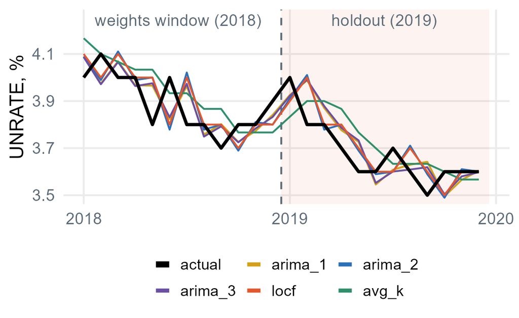

UNRATE 2018-2019, actuals in black. **meanf** is off the chart, near 6.0%.

Why $k=3$ for UNRATE, and not $k=24$?

## The course simulation: one track is genuinely better

$$(1-0.7L)(1-0.5L^{12})\,y_t=\alpha+\epsilon_t,\qquad \epsilon_t\sim N(0,1),\qquad \alpha=5(1-0.7)(1-0.5)=0.75,\qquad \mu=5$$

| Track | In the simulation |  |
| --- | --- | --- |
| `arima_1` | ARIMA(1,0,0)(1,0,0)$_{12}$, mean | **true specification** |
| `arima_2` | ARIMA(1,0,0), mean | misses the season |
| `arima_3` | ARIMA(0,1,1) | a needless difference |
| `locf`, `avg_k`, `meanf` | $k=1$, $3$, $t-1$ | as on UNRATE |

Each ARIMA estimated once, on 240 training months; then 12 weights-window and 12 holdout dates.

Built so the optimal weights are far from $1/M$: a method that finds `arima_1` should beat the simple average.

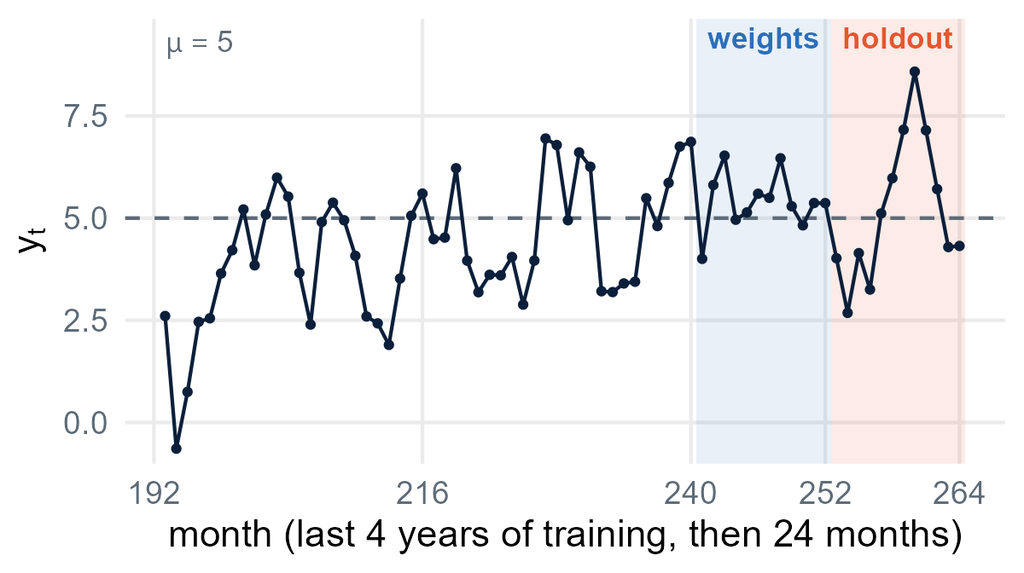

The course realization (seed 6376): the end of training, then the weights window and the holdout.

## Three ways to run an evaluation

| Scheme | Parameters | Estimation window at origin $t$ | Fits per model |
| --- | --- | --- | --- |
| **Fixed-parameter one-step** (PS3) | estimated once | $1{:}T$; information rolls to $t-1$ | 1 |
| Expanding window | re-estimated at every origin | $1{:}(t-1)$ | one per origin |
| Fixed-width rolling window | re-estimated at every origin | $(t-W){:}(t-1)$ | one per origin |

**Module 7 builds only the first row.** The other two re-estimate at every origin.

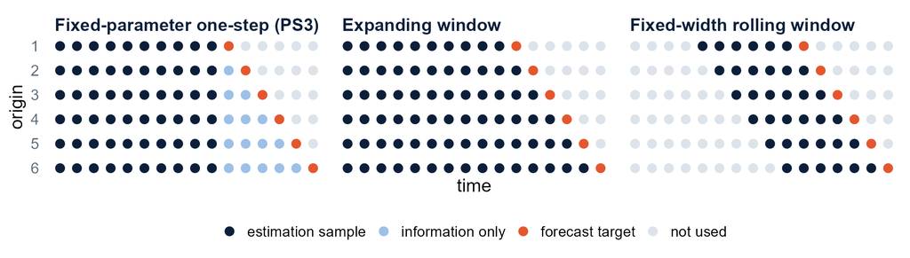

Re-estimation buys robustness to change at the cost of noisier parameters. Fixed-width windows forget old regimes on purpose.

Which scheme would you use if you suspected a break in 2008?

## $U_2$ and MASE answer different questions

RMSE and MAE are in units of $y$; MAPE is a percentage. Is 0.1 points good? Two relative scores, two different questions.

**$U_2$: a race.** Did model $m$ beat `locf` on these holdout dates?

$$U_2^{(m)}=\frac{\text{RMSE}^{(m)}}{\text{RMSE}^{(\texttt{locf})}}$$

Both RMSEs over the same holdout dates, $t=T{+}13,\ldots,T{+}24$.

$U_2<1$beat `locf` here

$U_2>1$lost to it here

**MASE (mean absolute scaled error): a yardstick.** Model $m$’s holdout miss, relative to the naive’s typical one-step miss *in training*.

$$\text{MASE}^{(m)}=\frac{\text{MAE}^{(m)}_{\text{holdout}}}{\text{MAE}^{(\texttt{locf})}_{\text{train}}}$$

$$\text{MAE}^{(m)}_{\text{holdout}}=\frac{1}{N}\sum_{t=T+13}^{T+24}\bigl\lvert y_t-\tilde y^{(m)}_{t\mid t-1}\bigr\rvert$$

$$\text{MAE}^{(\texttt{locf})}_{\text{train}}=\frac{1}{T-1}\sum_{t=2}^{T}\bigl\lvert y_t-\tilde y^{(\texttt{locf})}_{t\mid t-1}\bigr\rvert$$

with $\tilde y^{(\texttt{locf})}_{t\mid t-1}=y_{t-1}$. Seasonal variant: $y_{t-s}$ replaces $y_{t-1}$, over $t=s{+}1,\ldots,T$, divided by $T-s$.

MASE = 0.6. Did your model beat the naive in the holdout?

You cannot tell: the naive’s holdout errors never enter MASE. MASE $<1$ does not mean you beat the naive; $U_2<1$ does.

Helpers `theil_u2(actual, forecast, benchmark)` and `mase(actual, forecast, train, m = 1)`: the helper’s `m` is the seasonal lag $s$. `accuracy()` differs: a seasonal MASE scale by default, and a different “Theil’s U”.

## The scorecard on UNRATE: small errors, no win

```r
metrics_table <- function(actual, Fmat, train) {
  bench <- Fmat[, "locf"]
  t(apply(Fmat, 2, function(f) c(
    RMSE = rmse(actual, f),
    MAE  = mae(actual, f),
    MAPE = mape(actual, f),
    MASE = mase(actual, f, train),
    U2   = theil_u2(actual, f, bench))))
}
metrics_table(y_h, F_h, train_un)   # 2019
```

Every credible track has MASE below 1. Did any of them beat `locf`?

| Track | RMSE | MAE | MAPE | MASE | $U_2$ |
| --- | --- | --- | --- | --- | --- |
| `arima_1` | 0.097 | 0.083 | 2.258 | 0.642 | 1.011 |
| `arima_2` | 0.097 | 0.079 | 2.127 | 0.607 | 1.016 |
| `arima_3` | 0.096 | 0.080 | 2.168 | 0.618 | 0.999 |
| `locf` | 0.096 | 0.075 | 2.030 | 0.580 | 1.000 |
| `avg_k` | 0.108 | 0.092 | 2.478 | 0.709 | 1.124 |
| `meanf` | 2.315 | 2.312 | 63.103 | 17.875 | 24.182 |

**No meaningful win:** `arima_3`’s 0.999 is a tie with `locf`. MASE 0.58 to 0.71, but $U_2$ 0.999 to 1.124 (`locf` is 1 by construction). 2019 was easy, for everyone, the naive included.

`meanf`: an I(1) series has no $\mu$ to converge to (Module 2).

## Scoring is not testing: the taste test

**A metrics table is a ranking, not a verdict.** Is the gap bigger than what the noise in twelve forecast errors would produce by chance?

Two coffee shops, one sip eachno verdict

Twelve mornings, one sip from eacha tally of the difference

Is the average difference zero?a paired $t$-test

Shop A won one sip. How many paired sips before you would bet on A?

The Diebold-Mariano test is a $t$-test on the loss differentials.

## Diebold-Mariano: a $t$-test on loss differentials

$$d_t=g(e_{1,t})-g(e_{2,t}),\qquad H_0\!:\ \mathbb{E}[d_t]=0$$

$$\bar d=\frac{1}{N}\sum_t d_t,\qquad \text{DM}=\frac{\bar d}{\hat\sigma_{\bar d}}\ \stackrel{a}{\sim}\ N(0,1)$$

$\hat\sigma_{\bar d}$: a standard error that **allows for serial correlation in $d_t$**. At $h=1$, `dm.test()` uses lag 0 only, $\hat\sigma_d/\sqrt N$ (after the small-sample correction): it **assumes $d_t$ is serially uncorrelated**, a condition on $d_t$, not merely on the errors.

**Out-of-sample errors only**never `residuals(fit)`

**Same dates, same loss**both on the same $N$

**The sign:** $\text{DM}<0$forecast 1 had the smaller loss

On the course simulation, the correctly specified model against the naive:

```r
es_h <- ys_h - Fs_h        # N x M holdout errors
dm.test(es_h[, "arima_1"], es_h[, "locf"],
        h = 1, power = 2)  # power 2: squared
d_sim <- es_h[, "arima_1"]^2 - es_h[, "locf"]^2
t.test(d_sim)$statistic
```

`dm.test()`DM = −0.90, p = 0.390

`t.test(d_sim)`t = −0.90

The same statistic: `dm.test()` applies the Harvey-Leybourne-Newbold correction and a $t_{N-1}$ reference. Named, not derived.

## Shrink the sample: DM power from $N=12$ to $120$

`arima_1`, correctly specified and estimated, has an expected-loss advantage over `locf` and `arima_2` on average. How often does DM *detect* it?

$R=200$ replications: a fresh series, the ARIMAs estimated once on 240 months, one-step tracks over the next 120, DM on the first $N$ dates.

At $N=12$, what share of replications reject in favour of `arima_1`: about 90%, 50%, or 20%?

| Rejecting for arima_1 | N=12 | N=24 | N=60 | N=120 |
| --- | --- | --- | --- | --- |
| arima_1 vs locf | 12.5% | 40.5% | 76.0% | 95.5% |
| arima_1 vs arima_2 | 10.0% | 29.0% | 60.5% | 86.0% |

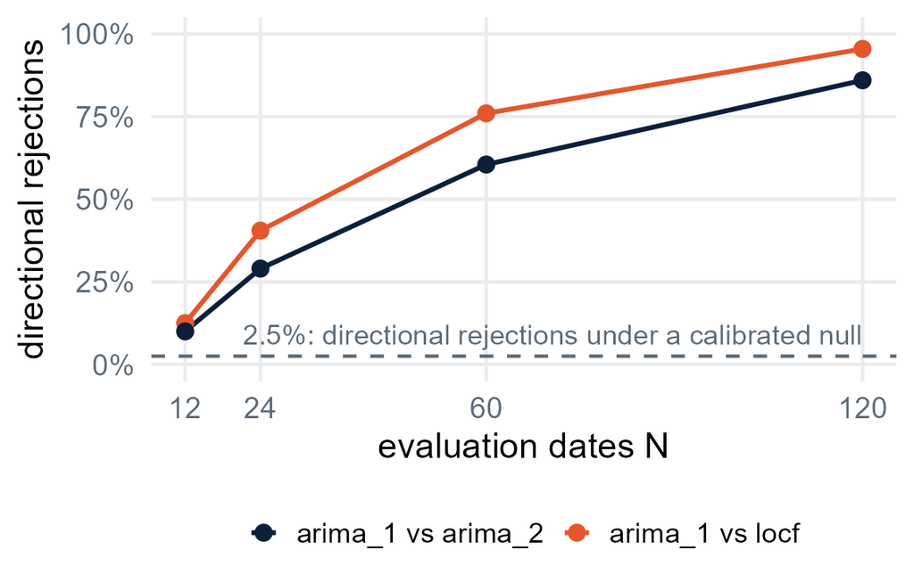

Mainly power: DM rejects when the gap is large relative to the variability of $d_t$. “Failed to reject” never means “equally good”.

Caveat: these are rates of the $h=1$ test, calibrated only if $d_t$ is serially uncorrelated. Under a calibrated null, 2.5% would reject in this direction (dashed line).

## Module 6’s question, answered

**Module 6:** on 2018-2019 the naive random walk beat the Module 5 SARIMA by a few hundredths. Does that margin mean anything?

Asked in the PS3 one-step design, on the 2019 holdout:

```r
e_h <- y_h - F_h          # N x M holdout errors
dm.test(e_h[, "arima_1"], e_h[, "locf"],
        h = 1, power = 2)
```

`arima_1` vs `locf`DM = 0.13, p = 0.90

Bartlett variance, `h = 2:4`p = 0.88 to 0.89

No: the test does not reject on these twelve months.

**What it does not claim.**

It does not test Module 6’s 24-step path. Errors from one origin share the early shocks and their spread grows with $h$: not the sequence DM assumes.

It does not say the two are equally good. Twelve dates rarely separate even a correctly specified estimated model from a misspecified one.

It is not assumption-free: $h=1$ assumes $d_t$ is serially uncorrelated. A variance that allows for serial correlation gives the same verdict (a low-power check).

## If you can’t pick a winner, why pick?

**On UNRATE** the five credible tracks are descriptively close, holdout RMSE 0.096 to 0.108, and the one tested comparison, `arima_1` vs `locf`, does not reject. Picking the winner of a twelve-month race is mostly picking noise.

Each forecast carries some information, and the loser may carry information the winner lacks.

**The portfolio analogy.** Forecasts are assets; forecast errors are their risks. Imperfectly correlated errors diversify, as imperfectly correlated returns do.

Bates and Granger (1969)weight by accuracy

Granger and Ramanathan (1984)weights as a regression

Stock and Watson (2004)name the puzzle

Did the crowd mean beat most of you? Why might it?

## A combined forecast is a weighted sum of forecasts

$$\tilde y^{(c)}_{t\mid t-1}=w_0+\sum_{m=1}^{M}w_m\,\tilde y^{(m)}_{t\mid t-1}=w_0+\mathbf{w}'\tilde{\mathbf{y}}_t$$

$\tilde{\mathbf{y}}_t$the $M\times1$ vector of the $M$ forecasts of $y_t$

$w_m$, $\mathbf{w}$the weight on forecaster $m$; the $M\times1$ weight vector

$w_0$an intercept: zero for every method but one

$e_{c,t}=y_t-\tilde y^{(c)}_{t\mid t-1}$the combined error; $c$ is a label, not an index

**Hats, stars and nothing,** the DGP-versus-estimation rule applied to weights:

$w$generic, or a fixed rule ($1/M$)

$\hat w$estimated on the weights window

$w^*$the population optimum

Weights are always $w$, never $\alpha$ or $\beta$ (taken). Enders writes $\alpha_0,\ldots,\alpha_n$.

## Two forecasts: the combined error variance

Weights $w$ and $1-w$ sum to one, so the combined error is the same mix of the two errors:

$$e_{c,t}=w\,e_{1,t}+(1-w)\,e_{2,t}$$

$$\begin{aligned}\text{Var(}e_{c,t}\text{)}&=w^2\,\text{Var(}e_{1,t}\text{)}+(1-w)^2\,\text{Var(}e_{2,t}\text{)}\\&\quad+2w(1-w)\,\text{Cov(}e_{1,t},e_{2,t}\text{)}\end{aligned}$$

Minimise over $w$ (Enders 2.73):

$$w^*=\frac{\text{Var(}e_{2,t}\text{)}-\text{Cov(}e_{1,t},e_{2,t}\text{)}}{\text{Var(}e_{1,t}\text{)}+\text{Var(}e_{2,t}\text{)}-2\,\text{Cov(}e_{1,t},e_{2,t}\text{)}}$$

With zero covariance, the **inverse-variance weight**:

$$w^*=\frac{1/\text{Var(}e_{1,t}\text{)}}{1/\text{Var(}e_{1,t}\text{)}+1/\text{Var(}e_{2,t}\text{)}}$$

**Error correlation** (two indices: not the lag-$k$ $\rho_k$):

$$\rho_{1,2}=\frac{\text{Cov(}e_{1,t},e_{2,t}\text{)}}{\sqrt{\text{Var(}e_{1,t}\text{)}\,\text{Var(}e_{2,t}\text{)}}}$$

**Variance ratio** $\text{Var(}e_{2,t}\text{)}/\text{Var(}e_{1,t}\text{)}\ge1$: forecast 1 is the better one.

**Diversification:** equal variances $V$, zero covariance: $w^*=0.5$ and $\text{Var(}e_{c,t}\text{)}=0.5V$. Averaging halves the error variance.

**Correlation eats the gain.** Among weights in $[0,1]$, the best mix beats forecast 1 alone until $\text{Cov(}e_{1,t},e_{2,t}\text{)}=\text{Var(}e_{1,t}\text{)}$, that is, $\rho_{1,2}=\sqrt{\text{Var(}e_{1,t}\text{)}/\text{Var(}e_{2,t}\text{)}}$.

**Past that threshold, $w^*>1$:** the formula **shorts** the worse forecast. Unconstrained regression weights do exactly this (Method 3).

## Drag the weight, the correlation, the variance ratio

[interactive chart not shown]

## Method 1: the simple average

$$w_0=0,\qquad w_m=\frac{1}{M}$$

**Nothing is estimated**, so the weights carry no hat. That is the whole point: the zero-estimation-error benchmark that every other method has to beat.

It is the radar’s crowd mean: every forecaster gets one vote, $1/M$ of the result.

Every method fits on the weights window ($T_w=12$ actuals and the $T_w\times M$ forecasts of them) and is then applied, unchanged, to the holdout forecasts.

```r
comb_simple <- function(y, F) {
  M <- ncol(F)   # y unused: common interface
  list(intercept = 0,
       weights = setNames(rep(1 / M, M),
                          colnames(F)))
}
```

## Method 2: inverse-MSE weights

$$\hat w_m=\frac{1/\text{MSE}_m}{\sum_{j=1}^{M}1/\text{MSE}_j},\qquad \text{MSE}_m=\frac{1}{T_w}\sum_{t\in\text{weights}}e_{m,t}^2,\qquad \hat w_0=0$$

The $M$-forecast version of the zero-covariance $w^*$ (Bates and Granger 1969; Enders 2.74).

**$M$ numbers estimated, each from its own column.** Non-negative and summing to one by construction.

**MSE, not the error variance**, so a biased forecaster pays for its bias too.

```r
comb_inv_mse <- function(y, F) {
  mse <- colMeans((y - F)^2)
  list(intercept = 0,
       weights = (1 / mse) / sum(1 / mse))
}
```

## Method 3: Granger-Ramanathan

$$y_t=w_0+\sum_{m=1}^{M}w_m\,\tilde y^{(m)}_{t\mid t-1}+v_t,\qquad t\in\text{weights window}$$

**Unconstrained least squares with an intercept.** OLS on the weights window delivers $\hat w_0,\hat w_1,\ldots,\hat w_M$.

The intercept absorbs any bias; weights can be negative and need not sum to one.

With $M=6$ and $T_w=12$: seven numbers from twelve observations.

$v_t$ is the regression’s disturbance: not an innovation $\epsilon_t$, not a forecast error $e_{m,t}$.

```r
comb_gr <- function(y, F) {
  b <- coef(lm(y ~ F))
  w <- setNames(b[-1], colnames(F))
  w[is.na(w)] <- 0   # exactly collinear track
  list(intercept = unname(b[1]), weights = w)
}
```

Module 4 asked the same question of extra AR lags. Do parameters that fit the sample forecast?

## Method 4: constrained least squares

$$\hat{\mathbf{w}}=\arg\min_{\mathbf{w}}\sum_{t\in\text{weights}}\big(y_t-\mathbf{w}'\tilde{\mathbf{y}}_t\big)^2\quad\text{subject to}\quad w_m\ge0,\;\;\sum_{m=1}^{M}w_m=1,\qquad \hat w_0=0$$

**A quadratic program.** No intercept, weights in a box: non-negative and summing to one.

**The constraints do model selection:** several weights land exactly on zero, and the rest read as shares.

Stable, interpretable, cannot short a forecaster.

No separate intercept for bias adjustment; reweighting can reduce bias, but cannot eliminate a common same-direction bias shared by every forecast.

```r
comb_cls <- function(y, F) {
  M    <- ncol(F)
  Amat <- cbind(rep(1, M), diag(M))
  bvec <- c(1, rep(0, M))   # sum = 1; w >= 0
  w <- quadprog::solve.QP(crossprod(F),
         crossprod(F, y), Amat, bvec,
         meq = 1)$solution
  w <- pmax(w, 0); w <- w / sum(w)
  list(intercept = 0,
       weights = setNames(w, colnames(F)))
}
```

## Four methods, one dial

| Method | $w_0$ | $\sum w_m=1$ | $w_m\ge0$ | Numbers estimated from the window | Estimation risk |
| --- | --- | --- | --- | --- | --- |
| Simple average (SA) | 0 | yes | yes | 0 | none |
| Inverse-MSE | 0 | yes | yes | $M$, one column at a time | low |
| Constrained LS (CLS) | 0 | yes | yes | $M$, jointly, boxed in | moderate |
| Granger-Ramanathan (GR) | free | no | no | $M+1$, jointly, unrestricted | high |

The four, fit on the course simulation’s weights window:

|  | simple avg | inverse-MSE | constrained LS | Granger- Ramanathan |
| --- | --- | --- | --- | --- |
| $\hat w_0$ | 0.00 | 0.00 | 0.00 | 261.70 |
| `arima_1` | 0.17 | 0.27 | 0.66 | 0.78 |
| `arima_2` | 0.17 | 0.14 | 0.00 | 1.88 |
| `arima_3` | 0.17 | 0.11 | 0.00 | −2.04 |
| `locf` | 0.17 | 0.09 | 0.00 | 0.00 |
| `avg_k` | 0.17 | 0.16 | 0.00 | −0.83 |
| `meanf` | 0.17 | 0.23 | 0.34 | −50.83 |

**Read it as a dial.** The simple average estimates nothing; inverse-MSE a little; CLS more, inside a box; Granger-Ramanathan everything.

CLS finds `arima_1`. Granger-Ramanathan’s intercept is 262 on a series whose mean is 5.

Which end of the dial wins on data the weights have not seen?

## A combination method is an estimator

**Theory says Granger-Ramanathan should win.** It minimises the weights-window sum of squared errors over all intercepts and weights: no other weights can fit that window better.

**But the fit is in-sample**, and its weights are estimates from twelve observations. Estimates carry error.

The assumption we break: that you know the weights.

**The experiment is fair.** The course DGP has a dominant track, `arima_1`, so the optimal weights are far from $1/M$.

A method that finds `arima_1` *should* beat the simple average. Can it, with $T_w=12$?

## Stage 1: weights that win the window they were fit on

| RMSE | Weights window | Holdout |
| --- | --- | --- |
| `arima_1` | 0.706 | 1.120 |
| `arima_2` | 0.979 | 1.208 |
| `arima_3` | 1.115 | 1.372 |
| `locf` | 1.208 | 1.301 |
| `avg_k` | 0.922 | 1.793 |
| `meanf` | 0.769 | 1.701 |
| simple avg | 0.877 | 1.284 |
| inverse-MSE | 0.804 | 1.281 |
| constrained LS | 0.681 | 1.237 |
| **Granger-Ramanathan** | **0.282** | **3.009** |

One realization (seed 6376), $T_w=12$: the §7.6 weights, scored on the window they were fit on and on the holdout.

Granger-Ramanathan, weights window0.282

simple average; `arima_1`0.877; 0.706

Granger-Ramanathan, holdout3.009

Best in the window, worst on the holdout: almost as many weights as observations, fitting the noise.

The other three sit close together; CLS, which found `arima_1`, is the best of them.

## Scoring a method: holdout RMSE relative to the simple average

$$\text{relative RMSE}_{\text{method}}=\frac{\text{RMSE of the method's combination on the holdout}}{\text{RMSE of the simple average on the same holdout}}$$

Below 1beat the simple average

Equal to 1a tie

Above 1lost to it

Weights fit on the weights window; scored on the 12 holdout dates the weights never saw.

Not $U_2$. $U_2$ divides by `locf`’s RMSE; this ratio divides by the simple average’s. Same dates, a different benchmark.

**Over $R=200$ simulated series**, one ratio per replication. Three summaries:

**Median**the typical replication

**90th percentile**the bad case: the right tail

**Share beating the simple average**fraction of replications below 1

## Stage 2: 200 replications at a 12-date weights window

Each replication (seed 6378): a fresh series, the ARIMAs estimated once, six tracks, four methods fit on $T_w=12$, scored on the 12-date holdout relative to the simple average.

Granger-Ramanathan beats the simple average in about 80%, 50%, or 15% of replications?

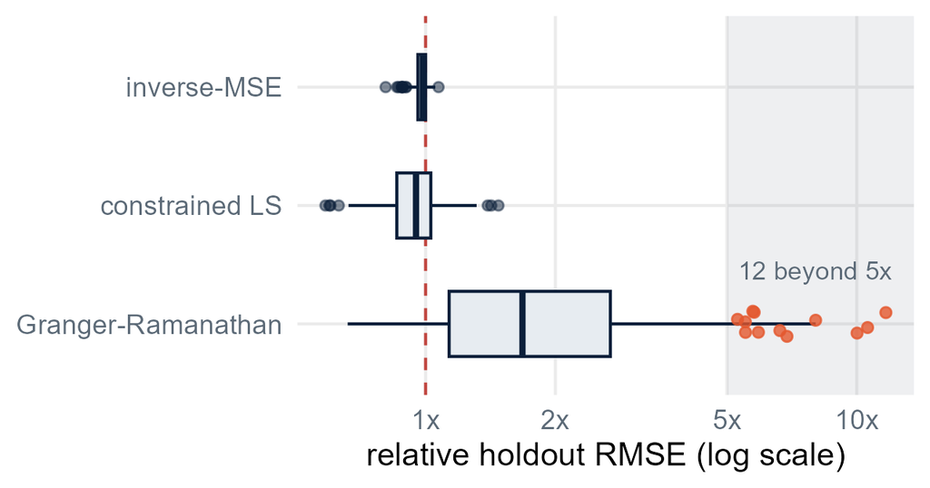

Every ratio above 5× is drawn (orange) in the shaded band: 12 of Granger-Ramanathan’s 200, the largest 11.7×; in the widget they fill the hatched lane. The summaries use every replication.

|  | Median | 90th pct | Share < 1 |
| --- | --- | --- | --- |
| inverse-MSE | 0.99 | 1.01 | 74.5% |
| constrained LS | 0.95 | 1.12 | 64.0% |
| **Granger-Ramanathan** | **1.68** | **4.07** | **16.0%** |

**The long right tail is the puzzle in one picture.** Inverse-MSE is the simple average with a tilt (median 0.99); CLS beats the simple average at the median (0.95).

## Stage 3: how long a window do estimated weights need?

[interactive chart not shown]

## The forecast combination puzzle

Theory says optimally weighted combinations should dominate. In practice, the simple average is very hard to beat. Stock and Watson (2004)

**Three lessons from the simulation.**

**1.** **A combination method is an estimator.** Holdout performance = the population gain from its weights minus the estimation error in them.

**2.** **The puzzle is a comparison: attainable gain against estimation cost.** It bites when the gain over equal weights is small relative to the cost of estimating the weights: near-equal optimal weights, or redundant forecasts. Twelve weights-window dates make the cost high, as in most applied work, and PS3.

**3.** **Restrictions are a dial.** Moving down from $1/M$ pays only when the window is long or the gain is large.

**The index fund.** Active managers (estimated weights) should beat the index (equal weights): they pick the winners. In practice fees eat the edge. Here the fee is estimation error.

**But** an index fund that holds a bankrupt stock at full weight is not a good index. Equal weights are robust to estimation error, not to a broken member of the pool.

## UNRATE: weights fit on 2018

```r
ws_un <- list(SA   = comb_simple(y_w, F_w),
              IMSE = comb_inv_mse(y_w, F_w),
              CLS  = comb_cls(y_w, F_w),
              GR   = comb_gr(y_w, F_w))
sapply(ws_un, function(w)
  c(w0 = w$intercept, w$weights))
kappa(cbind(1, F_w), exact = TRUE)
```

Condition number, GR design matrix41,620

Before the holdout: which of the four will the simple average beat on 2019?

|  | simple avg | inverse-MSE | constrained LS | Granger- Ramanathan |
| --- | --- | --- | --- | --- |
| $\hat w_0$ | 0.000 | 0.000 | 0.000 | −141.450 |
| `arima_1` | 0.167 | 0.235 | 0.690 | 1.224 |
| `arima_2` | 0.167 | 0.158 | 0.000 | −5.825 |
| `arima_3` | 0.167 | 0.229 | 0.000 | 1.088 |
| `locf` | 0.167 | 0.179 | 0.000 | 5.098 |
| `avg_k` | 0.167 | 0.198 | 0.310 | −2.605 |
| **`meanf`** | **0.167** | **0.001** | **0.000** | **24.803** |

Over twelve months the expanding mean of 696+ observations barely moves: the `meanf` column is almost a constant, almost collinear with the intercept.

## UNRATE: scored on 2019

| 2019 | Holdout RMSE |
| --- | --- |
| `arima_1` | 0.097 |
| `arima_2` | 0.097 |
| `arima_3` | 0.096 |
| `locf` | 0.096 |
| `avg_k` | 0.108 |
| `meanf` | 2.315 |
| **simple avg** | **0.416** |
| **inverse-MSE** | **0.093** |
| **constrained LS** | **0.094** |
| **Granger-Ramanathan** | **0.463** |

**Simple average**0.416

credible single tracks0.096 to 0.108

**Inverse-MSE**; **CLS**0.093; 0.094

**Granger-Ramanathan**0.463

Of the four combinations, the simple average beat only Granger-Ramanathan.

Inverse-MSE and CLS match or edge out the best single tracks; the simple average is roughly four times their RMSE.

## UNRATE: each estimated-weight combination against the simple average

**Three tests, declared in advance, all reported.**

```r
comb_h <- sapply(ws_un, function(w)   # N x 4
  w$intercept + F_h %*% w$weights)
ec_h <- y_h - comb_h      # combined errors
for (m in c("IMSE", "CLS", "GR"))
  print(dm.test(ec_h[, m], ec_h[, "SA"],
                h = 1, power = 2))
```

Never pick the holdout winner and then test it on the same twelve dates: that chooses the hypothesis after seeing the data.

| Against the simple average | DM | $p$ |
| --- | --- | --- |
| Inverse-MSE | −9.1 | $1.9\times10^{-6}$ |
| CLS | −9.1 | $1.8\times10^{-6}$ |
| Granger-Ramanathan | 0.87 | 0.40 |

Inverse-MSE and CLS: a clear rejection at $N=12$, the power lesson from the other side. Granger-Ramanathan: no detectable difference.

The $h=1$ check, all four UNRATE tests: Ljung-Box $p$ = 0.58 to 0.97 on $d_t$ (little power at $N=12$); Bartlett variance, `h = 2:4`: no verdict changes.

## The honest reading: a broken member, not a lucky estimate

**Here the attainable gain is large.** `meanf` has no business on an I(1) series, and $1/M$ gives it a sixth of the vote: enough to drag the average about 0.39 points off the actuals every month.

**Inverse-MSE and CLS won by down-weighting it**, which is exactly what estimated weights are for: that gain pays for estimating the restricted weights.

**Granger-Ramanathan lost for the Stage 1 reason**, amplified by near-collinearity: the intercept and the nearly constant `meanf` column are almost the same regressor.

Caveats: one window, a calm glide with no turning point; the $h=1$ verdicts survive a low-power dependence check, so robust, not definitive. One realization is one draw; the Monte Carlo is the distribution.

**For Problem Set 3:** look at your six tracks before you combine them. If one is broken on your series, say so, explain why from the series’ properties, and expect it to drag the simple average.

Equal weights are robust to estimation error. What are they not robust to?

A broken member of the pool.

## Key takeaways + next time

**1.** **Many origins, one horizon.** Estimate once; roll the information set.

**2.** **$U_2$:** did you beat the naive here? **MASE:** how big was the miss against the naive’s training miss?

**3.** **A metrics table is a ranking, not a verdict.** DM is a $t$-test on $d_t$ ($h=1$: assumes serially uncorrelated $d_t$); twelve dates buy little power. UNRATE: five tracks descriptively close; `arima_1` vs `locf` does not reject.

**4.** **Combine because errors diversify.** Zero covariance: weights $\propto$ inverse error variance.

**5.** **A combination method is an estimator.** With $T_w=12$, estimate as little as you can.

**6.** **Equal weights are the benchmark to beat, when the pool is sound.** The puzzle: estimation cost outweighs the attainable gain.

**7.** **Every forecast here used only the series’ own past.**

**Next time, Module 8: ADL models.**

What if an exogenous regressor could improve the forecast?

$$y_t=\alpha+\beta x_t+\sum_{j=1}^{p}\phi_j y_{t-j}+\epsilon_t$$

A new slider on the mixing board: $\beta x_t$ and its lags. Combinations only reshuffle the information already in the pool.

## Interactive lab machinery

This uncounted support slide keeps both widget factories in the document. Use the RevealJS menu to return to a widget if a browser reload interrupts an interaction.